# Laboratorio 03

Pablo González

7/4/2021

# Ejercicio 1 - Operaciones básicas

## Pregunta 1

Mediante el uso de R, genere las siguientes secuencias:

- 1 2 3 4 5 1 2 3 4 5 1 2 3 4 5
- 1 1 1 2 2 2 3 3 3 4 4 4 5 5 5

```r
rep(1:5,3)
```

```
##  [1] 1 2 3 4 5 1 2 3 4 5 1 2 3 4 5
```

```r
rep(1:5,rep(3,5))
```

```
##  [1] 1 1 1 2 2 2 3 3 3 4 4 4 5 5 5
```

## Pregunta 2

Genere los siguientes vectores:

- $X_1 = \begin{pmatrix} 6^{2} & \sqrt{144} & \log_{10}(5!) \end{pmatrix}$
- $X_2 = \begin{pmatrix} sin(3.2) & 3\sqrt{10} & 21^{1/3} \end{pmatrix}$
- $X_3 = \begin{pmatrix} \log_{10}(154) & 0.5^{6}+8.9 & cos(3.7) \end{pmatrix}$

```r
x1 <- c(6^2,sqrt(144),log10(factorial(5)))
x2 <- c(sin(3.2),3*sqrt(10),21^(1/3))
x3 <- c(log10(154),0.5^6+8.9,cos(3.7))
```

Realice las siguientes operaciones:

- $X_1+X_2+X_3$
- $3X_1+X_2$
- $X_1 \odot X_2$
- $X_1 \times X_2$

```r
x1 + x2 + x3
```

```
## [1] 38.129147 30.402458  3.990005
```

```r
3*x1 + x2
```

```
## [1] 107.941626  45.486833   8.996468
```

```r
x1*x2
```

```
## [1]  -2.101469 113.841996   5.736303
```

```r
x1%*%x2
```

```
##          [,1]
## [1,] 117.4768
```

## Pregunta 3

Una las matrices por filas y por columnas, llamando al resultado A y B respectivamente. Luego, realice las siguientes operaciones:

- $A+B$
- $A-3B$
- $¿Es\:A\:igual\:a\:B'?$

```r
A <- rbind(x1,x2,x3)
B <- cbind(x1,x2,x3)
A+B
```

```
##         [,1]     [,2]      [,3]
## x1 72.000000 11.94163  4.266702
## x2 11.941626 18.97367 11.674549
## x3  4.266702 11.67455 -1.696200
```

```r
A-3*B
```

```
##          [,1]        [,2]       [,3]
## x1 -72.000000  12.1751224  -4.483381
## x2 -36.058374 -18.9736660 -23.987951
## x3  -4.050023   0.6388525   1.696200
```

```r
A == t(B)
```

```
##    [,1] [,2] [,3]
## x1 TRUE TRUE TRUE
## x2 TRUE TRUE TRUE
## x3 TRUE TRUE TRUE
```

## Pregunta 4

$$\begin{pmatrix} 2 & 1 & -1 \\ 1 & -2 & 2 \\ 3 & -2 & 1 \end{pmatrix}X =
\begin{pmatrix} 1 \\ 3 \\ 2 \end{pmatrix}$$

```r
C <- matrix(c(2,1,3,1,-2,-2,-1,2,1),nrow=3,ncol=3)
D <- c(1,3,2)
```

```r
solve(C, D)
```

```
## [1] 1 2 3
```

```r
C%*%solve(C,D)
```

```
##      [,1]
## [1,]    1
## [2,]    3
## [3,]    2
```

$$\begin{pmatrix} 2 & 1 & -1 \\ 1 & -2 & 2 \\ 3 & -2 & 1 \end{pmatrix} \times
\begin{pmatrix} 1 \\ 2 \\ 3 \end{pmatrix} = \begin{pmatrix} 1 \\ 3 \\ 2 \end{pmatrix}$$

# Ejercicio 2 - Manejo de paquétes

## Pregunta 1

Instale el paquete “tictactoe” y cárguelo. Busque información acerca del paquete. ¿Qué es lo que hace? Si un robot de nivel 4 se enfrenta 1000 veces a uno de nivel 5, ¿cuál sería la proporción de empates, victorias y derrotas?

```r
if (!require('tictactoe')) install.packages('tictactoe'); library('tictactoe')
#ttt(ttt_human(), ttt_ai(level = 4))
prop.table(table(ttt_simulate(ttt_ai(level = 5), ttt_ai(level = 4), N = 1000, verbose = FALSE)))
```

```
##
##     0     1
## 0.911 0.089
```

## Pregunta 2

Instale el paquete “coronavirus” desde Github. ¿En qué consiste este paquete y en qué se diferencia de su versión en CRAN?

```r
if (!require('devtools')) install.packages('devtools'); library('devtools')
if (!require('coronavirus')) devtools::install_github("covid19r/coronavirus")
```

## Pregunta 3

¿Qué país ha tenido la mayor cantidad de casos confirmados en un mismo día? ¿Y la menor?

```r
coronavirus <- force(coronavirus::coronavirus)
filtro1 = which(coronavirus$cases == max(coronavirus$cases[coronavirus$type == "confirmed"]))
filtro2 = which(coronavirus$cases == min(coronavirus$cases[coronavirus$type == "confirmed"]))
coronavirus$Country.Region[filtro1]
```

```
## [1] "US"
```

```r
coronavirus$Country.Region[filtro2]
```

```
## [1] "Spain"
```

## Pregunta 4

Grafique la cantidad de casos acumulados en Chile en el tiempo

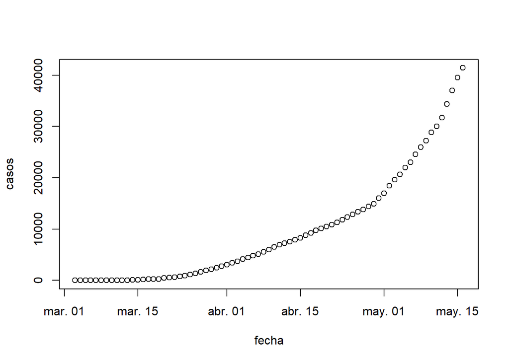

```r
filtro = coronavirus$Country.Region=="Chile" & coronavirus$type=="confirmed"
fecha <- coronavirus$date[filtro]
casos <- coronavirus$cases[filtro]
chile <- data.frame(fecha,casos = cumsum(casos))
chile <- chile[chile$casos>0,]
rm(fecha,casos)
plot(chile)
```

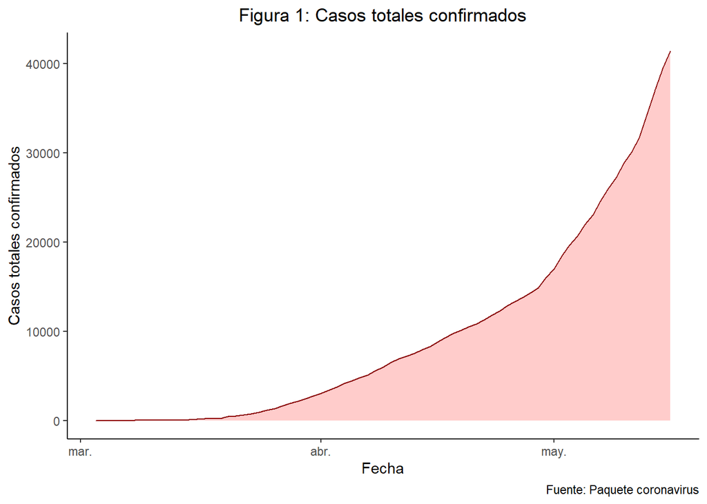

```r
# Con mejor diseño
if (!require('ggplot2')) install.packages('ggplot2'); library('ggplot2')
ggplot(chile, aes(x=fecha,y=casos)) + geom_area(color="darkred", fill="#ffcccb") +
  theme_classic() +
  labs(x = "Fecha", y = "Casos totales confirmados",
       title = "Figura 1: Casos totales confirmados",
       caption = "Fuente: Paquete coronavirus") + theme(plot.title = element_text(hjust = 0.5))
```